# Analysis of RNAseq Data from Human Pancreatic Islets

PI Charlotte Ling, Lund University

Nikolay Oskolkov, SciLifeLab, NBIS Long Term Support, nikolay.oskolkov@scilifelab.se

January 14, 2020

Abstract

Here we will use the RNAseq data from Human Pancreatic Islets from individuals with and without Type 2 Diabetes (T2D) and perform diebetes status linear predictive analysis with PLS-DA model on 110 manually selected individuals with most reliable phenotypic information.

### The List of 110 Selected Individuals

All the analysis will be performed on the 110 individuals whic were selected based on multiple criteria such as 1) they are either normo-glycimic or hyper-glycemic / T2D individuals, 2) they have information from all the 4 OMICS (methylation, transcriptomics, phenotypes, genotypes), 3) they all fall within the same age category, and a few other minor criteria. Now we will read the list of those 110 individuals and display a few of them:

```r
set.seed(1)
selected_ind<-scan("OVERLAPPING_110_SAMPLES_4OMICS.txt", what = "charater")
selected_ind<-paste0("ID",selected_ind)
print(head(selected_ind, 20))
```

```
##  [1] "ID1"  "ID3"  "ID4"  "ID6"  "ID8"  "ID10" "ID14" "ID19" "ID21" "ID30"
## [11] "ID32" "ID34" "ID35" "ID36" "ID38" "ID39" "ID44" "ID46" "ID55" "ID58"
```

```r
print(tail(selected_ind, 20))
```

```
##  [1] "ID136" "ID156" "ID160" "ID165" "ID168" "ID172" "ID175" "ID182"
##  [9] "ID183" "ID191" "ID194" "ID200" "ID209" "ID210" "ID214" "ID217"
## [17] "ID221" "ID228" "ID263" "ID273"
```

### Checking Human Islets Phenotypes

We will start with the analysis of phenotypes available from approximately 300 Human Panctreatic Islets in order to check the relation between the phenotypes. Later this information will be taken into account when we do batch-effects correction. The phenotype file below was provided by Human Tissue Lab (HTL) from Lund University Diabetes Center (LUDC), it includes phenotypic information from approximately 300 pancreatic islets donors. Not all of them will overlap with the methylation EPIC array, RNAseq and genotyping array samples but we still will use the info from all available donors in order to establish how phenotypes are correlated with each other. We start with reading the file and removing non-relevant phenotypes:

- HTL_donor_ID: Human Tissue Lab Donor ID)
- NICS_donor_ID: Uppsala donor ID
- Birth: redundant, captured by Age variable
- HbA1c_mmol_mol: redundant, captured by HbA1c_perc
- Blood_group: unlikely to be related to Type 2 Diabetes
- Non_diabetic: redundant, captured by T2D variable
- GAD: not related to T2D
- Gestational: appropriate only for females, will be correlated with Sex
- Date_isolated_islets: unlikely to be related to Type 2 Diabetes
- Date_recieved_islets: unlikely to be related to Type 2 Diabetes
- Islet_equivalences: unlikely to be related to Type 2 Diabetes
- Diabetes_treatment: too sparse information

We will also add information about Methylation EPIC Array batches and RNAseq batches (old vs. new chemistry) in order to see what phenotypes the batches correlate with. This is a potential denger if the batches happen to correlate with valuables phenotypes like T2D or HbA1c. As a control of noise level we will introduce a random variable, we will use it to check later how much of phenotypic variation can be explained by chance.

```r
htl<-read.csv("htl_donors.csv",header=TRUE,check.names=FALSE)
htl$HTL_donor_ID<-paste0("ID",htl$HTL_donor_ID)
phen_meth_array_batch<-read.delim("phenotypes_islets.txt",header=TRUE,row.names=1,check.names=FALSE,sep="\t")
htl$Meth_Batch<-phen_meth_array_batch$batch[match(as.character(htl$HTL_donor_ID),rownames(phen_meth_array_batch))]
htl$Meth_Batch[is.na(htl$Meth_Batch)]<-21
phen_rnaseq_batch<-readRDS("phenotypes.RData")
htl$RNA_Batch<-phen_rnaseq_batch$batch[match(as.character(htl$HTL_donor_ID),paste0("ID",gsub("Sample_","",phen_rnaseq_batch$sample_id)))]
htl$Random<-log(sample(dim(htl)[1]))
rownames(htl)<-htl$HTL_donor_ID

htl$HTL_donor_ID<-NULL
htl$NICS_donor_ID<-NULL
htl$Birth<-NULL
htl$HbA1c_mmol_mol<-NULL
htl$Blood_group<-NULL
htl$Non_diabetic<-NULL
htl$GAD<-NULL
htl$Gestational<-NULL
htl$Date_isolated_islets<-NULL
htl$Date_recieved_islets<-NULL
htl$Islet_equivalences<-NULL
htl$Diabetes_treatment<-NULL
htl$RNA_Batch<-as.numeric(htl$RNA_Batch)
head(htl)
```

```
##     Gender Age  BMI HbA1c_perc T2D Stimulatory_index Purity_perc
## ID1   Male  68 24.7        5.8   0               9.6          75
## ID2   Male  55 24.7         NA   0              10.2          90
## ID3 Female  45 23.9        5.4   0               3.6          70
## ID4 Female  61 27.7         NA   0              14.9          80
## ID5 Female  69 17.6         NA   0              10.9          37
## ID6   Male  67 28.4        5.5   0               1.9          95
##     Days_cultured Meth_Batch RNA_Batch   Random
## ID1             5          1        11 5.117994
## ID2             8         21        11 4.859812
## ID3             3          1        10 5.598422
## ID4             5         21        11 5.231109
## ID5             2         21        11 4.442651
## ID6             2          1        11 5.624018
```

For convenience we will rename HbA1c_perc to HbA1c, Stimulatory_index to SI, Purity_perc to Purity, Days_cultured to DIC. We will also assign donors with HbA1c > 6.5 to diabetics and balance the data set a bit better in this way.

```r
names(htl)[names(htl)=="HbA1c_perc"]<-"HbA1c"
names(htl)[names(htl)=="Stimulatory_index"]<-"SI"
names(htl)[names(htl)=="Purity_perc"]<-"Purity"
names(htl)[names(htl)=="Days_cultured"]<-"DIC"
htl$T2D<-ifelse( ((is.na(htl$T2D)==FALSE & htl$T2D==1) | (is.na(htl$HbA1c)==FALSE  & htl$HbA1c>6.5)), 1, 0)
head(htl)
```

```
##     Gender Age  BMI HbA1c T2D   SI Purity DIC Meth_Batch RNA_Batch
## ID1   Male  68 24.7   5.8   0  9.6     75   5          1        11
## ID2   Male  55 24.7    NA   0 10.2     90   8         21        11
## ID3 Female  45 23.9   5.4   0  3.6     70   3          1        10
## ID4 Female  61 27.7    NA   0 14.9     80   5         21        11
## ID5 Female  69 17.6    NA   0 10.9     37   2         21        11
## ID6   Male  67 28.4   5.5   0  1.9     95   2          1        11
##       Random
## ID1 5.117994
## ID2 4.859812
## ID3 5.598422
## ID4 5.231109
## ID5 4.442651
## ID6 5.624018
```

```r
for(i in 1:ncol(htl))
{
  if(length(levels(factor(htl[,i]))) > 2)
  {
    htl[,i]<-as.numeric(as.character(htl[,i]))
  }
  else
  {
    htl[,i]<-as.factor(htl[,i])
  }
}
```

Now we are going to select the 110 individuals with overlapping OMICs and keep only those individuals for further downstream analysis:

```r
htl<-htl[match(selected_ind,rownames(htl)),]
head(htl)
```

```
##      Gender Age  BMI HbA1c T2D   SI Purity DIC Meth_Batch RNA_Batch
## ID1    Male  68 24.7   5.8   0  9.6     75   5          1        11
## ID3  Female  45 23.9   5.4   0  3.6     70   3          1        10
## ID4  Female  61 27.7    NA   0 14.9     80   5         21        11
## ID6    Male  67 28.4   5.5   0  1.9     95   2          1        11
## ID8    Male  51 27.0   4.3   0 37.3     75   2         14        10
## ID10 Female  60 26.1    NA   0  5.6     75   2         21        11
##        Random
## ID1  5.117994
## ID3  5.598422
## ID4  5.231109
## ID6  5.624018
## ID8  4.369448
## ID10 3.610918
```

Now let us calculate pair-wise linear regression for the phenotypes and extract the adjusted R squared information which is equaivalent to the fraction of variation in the response variable explained by the predictor variable. In case the response variable is a factor, we will be using logistic regression (Generalized Linear Model, GLM, with family = “binomial”) and calculate the adjusted R suared as:

$$R^2_{adj} = 1 - \frac{\rm{Residual Deviance}}{\rm{Null Deviance}}$$

```r
phen_adj_r_squared<-matrix(NA,ncol=ncol(htl),nrow=ncol(htl))
for(i in 1:ncol(htl))
{
  print(i)
  for(j in 1:ncol(htl))
  {
    if(typeof(htl[,i])=="double" & (typeof(htl[,j])=="double" | typeof(htl[,j])=="integer"))
    {
      model<-suppressWarnings(lm(htl[,i]~htl[,j]))
      phen_adj_r_squared[j,i]<-suppressWarnings(summary(model)$adj.r.squared)
    }
    if(typeof(htl[,i])=="integer" & typeof(htl[,j])=="double")
    {
      model<-suppressWarnings(lm(htl[,j]~htl[,i]))
      phen_adj_r_squared[j,i]<-suppressWarnings(summary(model)$adj.r.squared)
    }
    if(typeof(htl[,i])=="integer" & typeof(htl[,j])=="integer")
    {
      model<-suppressWarnings(glm(htl[,i]~htl[,j],family="binomial"))
      phen_adj_r_squared[j,i]<-1-model$deviance/model$null.deviance
    }
  }
}
```

```
## [1] 1
## [1] 2
## [1] 3
## [1] 4
## [1] 5
## [1] 6
## [1] 7
## [1] 8
## [1] 9
## [1] 10
## [1] 11
```

```r
phen_adj_r_squared<-as.data.frame(phen_adj_r_squared)
colnames(phen_adj_r_squared)<-colnames(htl)
rownames(phen_adj_r_squared)<-colnames(htl)
phen_adj_r_squared[phen_adj_r_squared<0]<-0
phen_adj_r_squared
```

```
##                  Gender         Age         BMI       HbA1c          T2D
## Gender     1.0000000000 0.000000000 0.000000000 0.000000000 6.709567e-05
## Age        0.0000000000 1.000000000 0.000000000 0.000000000 0.000000e+00
## BMI        0.0000000000 0.000000000 1.000000000 0.021012675 3.241738e-02
## HbA1c      0.0000000000 0.000000000 0.021012675 1.000000000 5.635442e-01
## T2D        0.0000608413 0.000000000 0.032417382 0.563544161 1.000000e+00
## SI         0.0047175889 0.000000000 0.000000000 0.016919962 4.099784e-03
## Purity     0.0000000000 0.000000000 0.000000000 0.000000000 0.000000e+00
## DIC        0.0000000000 0.011359304 0.000000000 0.034193217 7.579456e-02
## Meth_Batch 0.0000000000 0.005251804 0.000000000 0.000000000 0.000000e+00
## RNA_Batch  0.0000000000 0.008559894 0.000000000 0.005603449 3.552439e-02
## Random     0.0000000000 0.000000000 0.001175757 0.000000000 7.923939e-03
##                     SI      Purity         DIC  Meth_Batch   RNA_Batch
## Gender     0.004717589 0.000000000 0.000000000 0.000000000 0.000000000
## Age        0.000000000 0.000000000 0.011359304 0.005251804 0.008559894
## BMI        0.000000000 0.000000000 0.000000000 0.000000000 0.000000000
## HbA1c      0.016919962 0.000000000 0.034193217 0.000000000 0.005603449
## T2D        0.004099784 0.000000000 0.075794563 0.000000000 0.035524389
## SI         1.000000000 0.000000000 0.000000000 0.017228281 0.011108185
## Purity     0.000000000 1.000000000 0.067372444 0.004887090 0.000000000
## DIC        0.000000000 0.067372444 1.000000000 0.004515378 0.005087206
## Meth_Batch 0.017228281 0.004887090 0.004515378 1.000000000 0.167254309
## RNA_Batch  0.011108185 0.000000000 0.005087206 0.167254309 1.000000000
## Random     0.011848277 0.002161258 0.000000000 0.000000000 0.000000000
##                 Random
## Gender     0.000000000
## Age        0.000000000
## BMI        0.001175757
## HbA1c      0.000000000
## T2D        0.007923939
## SI         0.011848277
## Purity     0.002161258
## DIC        0.000000000
## Meth_Batch 0.000000000
## RNA_Batch  0.000000000
## Random     1.000000000
```

Now we can plot the heatmap of the adjusted R squared statistics and check how phenotypes and batches are related to each other:

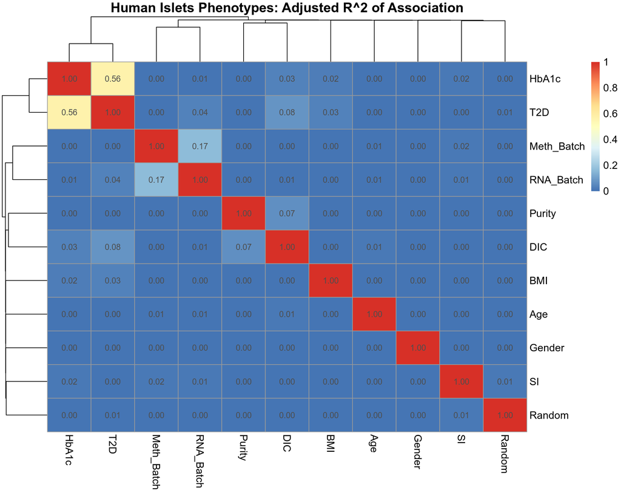

```r
library("pheatmap")
pheatmap(phen_adj_r_squared, display_numbers=TRUE, fontsize=12, main="Human Islets Phenotypes: Adjusted R^2 of Association")
```

We can see that HbA1c and T2D are very strongly connected, they should since the T2D diagnostics relies on blood glucose level measurements. They also seem to be weakly related with BMI which also makes sense. Despite Age and Gender are believed to be a risk factor for T2D, we do not observe a reliable association between those three phenotypes in our sample.

Meth_Batch and RNA_Batch are strongly connected which must imply that the RNA sequencing and EPIC array experiemnts were sinchonized in time. The Methylation batch happily do not seem to influence any of the important phenotypes, perhaps only the Stimulatory Index (SI). However the RNAseq batch seems to slightly confound the T2D variable which is not good news, this means that removing the RNAseq batch we can remove some of the T2D variation.

There is astrange/unexpected observation following from the heatmap: DIC seem to be strangly but weakly correlated with the T2D status. The random variable sets the noise level which seems to be 1% of explained variance in this data set implying that all correlations with explained variance equal or below this estimate are most likely due to noise.

### RNAseq Data from Human Pancreatic Islets

The raw unnormalized counts were provided by Alexander Perfiliev from Lund University Diabetes Center (LUDC), the counts were generated by Salmon pseudo-aligner. TPM normalization which is by default used by Salmon might not be fully robust dues to the conversion to Simplex Space which it automatically does where Euclidean distance is not valid any more so all statistical methods like PCA etc. should be used with caution or with Aitchinson distance instead of Euclidean. In order to avoid this complication, we applied TMM/DESeq normalization to the Salmon raw counts. Let us read the expression matrix, keep only genes with non-zero counts for all samples above, and have a look at the data:

```r
library("matrixStats")
expr<-suppressWarnings(as.data.frame(readRDS("export_deseq2_diabetes_nikolay.rds")))
rownames(expr)<-substr(rownames(expr),1,15)
colnames(expr)<-gsub("Sample_","ID",colnames(expr))
expr<-expr[rowSums(expr)!=0,]
expr<-subset(expr,select=selected_ind)
expr[1:10,1:9]
```

```
##                       ID1        ID3         ID4         ID6        ID8
## ENSG00000000003  585.3199  483.42784  411.953109  338.501760  202.79780
## ENSG00000000419  593.0215  507.59924  471.893376 1463.763670  374.22759
## ENSG00000000457  371.6011  218.43777  305.150451  179.508509  263.34534
## ENSG00000000460  133.8149   91.31415  135.138057   42.056279   70.76038
## ENSG00000000938    0.0000    5.37142    3.269469    5.128815   10.94233
## ENSG00000000971 1151.3858  342.87567  373.809303  790.863202  151.73360
## ENSG00000001036 1795.4303 2281.06324 1681.596951 2432.083855 2275.27459
## ENSG00000001084 2247.8980 1811.06394 1668.519074 2795.203925 1293.38308
## ENSG00000001167  951.1448  485.21832  863.139848  441.078051  708.33332
## ENSG00000001460  168.4720  217.54253  239.761069  296.445480  207.17473
##                        ID10        ID14        ID19        ID21
## ENSG00000000003  764.076014  313.289125  293.783107  355.005419
## ENSG00000000419  605.433113  410.009258  422.647061  408.131230
## ENSG00000000457  238.503954  326.605665  274.420130  228.128482
## ENSG00000000460  164.038918   57.471383   81.458043   83.751278
## ENSG00000000938    7.554424    6.307835    4.006133    4.375067
## ENSG00000000971  536.364095  517.242448  369.899639  201.878081
## ENSG00000001036 2337.554586 1975.053142 2147.955126 2119.407351
## ENSG00000001084 2504.831114 1702.414508 1937.633129 1780.027170
## ENSG00000001167  869.837948  810.206328  795.217456  961.264673
## ENSG00000001460  280.592887  225.680309  250.383330  193.127948
```

Thus here we have non-zero expression values from 19339 genes and 110 individuals. We have 32 diabetics in the initial meta info data set. Let us filter out genes with meadian count accross all samples below 1, this will remove lowly expressed genes which typically bring too much noise to the analysis. Let us also convert Ensembl IDs to gene symbols which will be easier to recognize and interpret.

```r
htl<-htl[match(colnames(expr),rownames(htl)),]
head(htl)
```

```
##      Gender Age  BMI HbA1c T2D   SI Purity DIC Meth_Batch RNA_Batch
## ID1    Male  68 24.7   5.8   0  9.6     75   5          1        11
## ID3  Female  45 23.9   5.4   0  3.6     70   3          1        10
## ID4  Female  61 27.7    NA   0 14.9     80   5         21        11
## ID6    Male  67 28.4   5.5   0  1.9     95   2          1        11
## ID8    Male  51 27.0   4.3   0 37.3     75   2         14        10
## ID10 Female  60 26.1    NA   0  5.6     75   2         21        11
##        Random
## ID1  5.117994
## ID3  5.598422
## ID4  5.231109
## ID6  5.624018
## ID8  4.369448
## ID10 3.610918
```

```r
expr<-expr[rowMedians(as.matrix(expr[,rownames(htl)[htl$T2D==0]]))>=1 | rowMedians(as.matrix(expr[,rownames(htl)[htl$T2D==1]]))>=1,]
#expr<-apply(expr,2,function(x) x/sum(x))

Ensembl2GeneSymbol<-read.delim("ENSEMBLE_TO_GENE_SYMBOL_COORD_GENCODE29.txt",header=TRUE,sep="\t")
head(Ensembl2GeneSymbol)
```

```
##   ensembl_gene_id external_gene_name chromosome_name start_position
## 1 ENSG00000223972            DDX11L1            chr1          11869
## 2 ENSG00000227232             WASH7P            chr1          14404
## 3 ENSG00000278267          MIR6859-1            chr1          17369
## 4 ENSG00000243485        MIR1302-2HG            chr1          29554
## 5 ENSG00000284332          MIR1302-2            chr1          30366
## 6 ENSG00000237613            FAM138A            chr1          34554
##   end_position
## 1        14409
## 2        29570
## 3        17436
## 4        31109
## 5        30503
## 6        36081
```

```r
IntersectGenes<-intersect(rownames(expr),as.character(Ensembl2GeneSymbol$ensembl_gene_id))
Ensembl2GeneSymbol<-Ensembl2GeneSymbol[match(IntersectGenes,as.character(Ensembl2GeneSymbol$ensembl_gene_id)),]
expr<-expr[match(IntersectGenes,rownames(expr)),]
rownames(expr)<-make.names(Ensembl2GeneSymbol$external_gene_name,unique=TRUE)
#refseq_hg38_genes<-scan("hg38_refseq_genes.txt",what="character")
#expr<-expr[rownames(expr)%in%refseq_hg38_genes,]

head(htl)
```

```
##      Gender Age  BMI HbA1c T2D   SI Purity DIC Meth_Batch RNA_Batch
## ID1    Male  68 24.7   5.8   0  9.6     75   5          1        11
## ID3  Female  45 23.9   5.4   0  3.6     70   3          1        10
## ID4  Female  61 27.7    NA   0 14.9     80   5         21        11
## ID6    Male  67 28.4   5.5   0  1.9     95   2          1        11
## ID8    Male  51 27.0   4.3   0 37.3     75   2         14        10
## ID10 Female  60 26.1    NA   0  5.6     75   2         21        11
##        Random
## ID1  5.117994
## ID3  5.598422
## ID4  5.231109
## ID6  5.624018
## ID8  4.369448
## ID10 3.610918
```

```r
dim(htl)
```

```
## [1] 110  11
```

```r
expr[1:6,1:6]
```

```
##                ID1       ID3        ID4         ID6       ID8       ID10
## TSPAN6    585.3199 483.42784 411.953109  338.501760 202.79780 764.076014
## DPM1      593.0215 507.59924 471.893376 1463.763670 374.22759 605.433113
## SCYL3     371.6011 218.43777 305.150451  179.508509 263.34534 238.503954
## C1orf112  133.8149  91.31415 135.138057   42.056279  70.76038 164.038918
## FGR         0.0000   5.37142   3.269469    5.128815  10.94233   7.554424
## CFH      1151.3858 342.87567 373.809303  790.863202 151.73360 536.364095
```

```r
dim(expr)
```

```
## [1] 18023   110
```

Therefore we have 32 diabetics in the meta info data set that matches the expression data set. Now the expression and meta data are ready for analysis and we will start with a simple PCA in order to look at batch effects and other biological and technical variation. Later, we will proceed with Partial Least Squares (PLS) regression and finally will use it for prediction of diabetes status.

### Preliminary Analysis with PCA

Now we will perform preliminary PCA analysis. Fo this purpose, the expression matrix, which we will refer to as *X*, needs to be transposed. We will keep only top 10 PCs for evaluation.

```r
library("mixOmics")
X<-as.data.frame(t(expr))
X[1:10,1:10]
```

```
##        TSPAN6      DPM1    SCYL3  C1orf112       FGR       CFH    FUCA2
## ID1  585.3199  593.0215 371.6011 133.81491  0.000000 1151.3858 1795.430
## ID3  483.4278  507.5992 218.4378  91.31415  5.371420  342.8757 2281.063
## ID4  411.9531  471.8934 305.1505 135.13806  3.269469  373.8093 1681.597
## ID6  338.5018 1463.7637 179.5085  42.05628  5.128815  790.8632 2432.084
## ID8  202.7978  374.2276 263.3453  70.76038 10.942327  151.7336 2275.275
## ID10 764.0760  605.4331 238.5040 164.03892  7.554424  536.3641 2337.555
## ID14 313.2891  410.0093 326.6057  57.47138  6.307835  517.2424 1975.053
## ID19 293.7831  422.6471 274.4201  81.45804  4.006133  369.8996 2147.955
## ID21 355.0054  408.1312 228.1285  83.75128  4.375067  201.8781 2119.407
## ID30 518.2982  415.6977 286.6196  87.37594  5.295512  417.0216 2069.221
##          GCLC     NFYA    STPG1
## ID1  2247.898 951.1448 168.4720
## ID3  1811.064 485.2183 217.5425
## ID4  1668.519 863.1398 239.7611
## ID6  2795.204 441.0781 296.4455
## ID8  1293.383 708.3333 207.1747
## ID10 2504.831 869.8379 280.5929
## ID14 1702.415 810.2063 225.6803
## ID19 1937.633 795.2175 250.3833
## ID21 1780.027 961.2647 193.1279
## ID30 1963.973 881.0408 201.8914
```

```r
dim(X)
```

```
## [1]   110 18023
```

```r
X<-log10(X+1)
X[1:10,1:10]
```

```
##        TSPAN6     DPM1    SCYL3 C1orf112       FGR      CFH    FUCA2
## ID1  2.768135 2.773802 2.571244 2.129738 0.0000000 3.061598 3.254410
## ID3  2.685229 2.706376 2.341311 1.965268 0.8042363 2.536401 3.358328
## ID4  2.615901 2.674763 2.485935 2.133980 0.6303739 2.573810 3.225980
## ID6  2.530842 3.165768 2.256498 1.634036 0.7873765 2.898650 3.386157
## ID8  2.309199 2.574295 2.422172 1.855885 1.0770890 2.183935 3.357225
## ID10 2.883705 2.782783 2.379313 2.217586 0.9321908 2.730269 3.368948
## ID14 2.497329 2.613852 2.515351 1.766943 0.8637887 2.714533 3.295799
## ID19 2.469503 2.627004 2.439996 1.916233 0.6995024 2.569256 3.332227
## ID21 2.551457 2.611863 2.360079 1.928146 0.7303839 2.307235 3.326419
## ID30 2.715417 2.619821 2.458818 1.946334 0.7990310 2.621199 3.316017
##          GCLC     NFYA    STPG1
## ID1  3.351970 2.978703 2.229098
## ID3  3.258174 2.686831 2.339536
## ID4  3.222591 2.936584 2.381586
## ID6  3.446569 2.645499 2.473407
## ID8  3.112063 2.850850 2.318428
## ID10 3.398952 2.939937 2.449622
## ID14 3.231320 2.909131 2.355414
## ID19 3.287496 2.901032 2.400336
## ID21 3.250671 2.983295 2.288088
## ID30 3.293357 2.945489 2.307264
```

```r
dim(X)
```

```
## [1]   110 18023
```

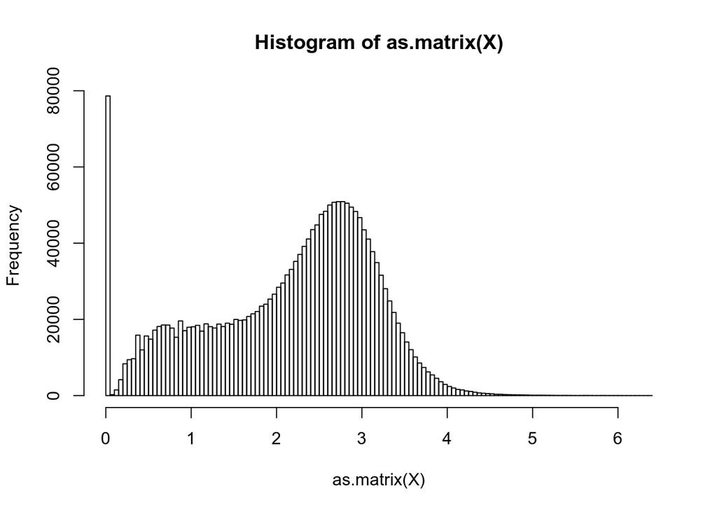

```r
hist(as.matrix(X),breaks=100)
```

```r
pca.expr<-pca(X, ncomp=10, center=TRUE, scale=TRUE)
pca.expr
```

```
## Eigenvalues for the first 10 principal components, see object$sdev^2:
##       PC1       PC2       PC3       PC4       PC5       PC6       PC7
## 3490.2759 1946.7266 1668.1536 1162.4847  929.9129  563.0370  467.9103
##       PC8       PC9      PC10
##  400.5820  374.9218  360.2542
##
## Proportion of explained variance for the first 10 principal components, see object$explained_variance:
##        PC1        PC2        PC3        PC4        PC5        PC6
## 0.19365677 0.10801346 0.09255693 0.06450007 0.05159590 0.03123991
##        PC7        PC8        PC9       PC10
## 0.02596184 0.02222616 0.02080241 0.01998858
##
## Cumulative proportion explained variance for the first 10 principal components, see object$cum.var:
##       PC1       PC2       PC3       PC4       PC5       PC6       PC7
## 0.1936568 0.3016702 0.3942272 0.4587272 0.5103231 0.5415630 0.5675249
##       PC8       PC9      PC10
## 0.5897510 0.6105535 0.6305420
##
##  Other available components:
##  --------------------
##  loading vectors: see object$rotation
```

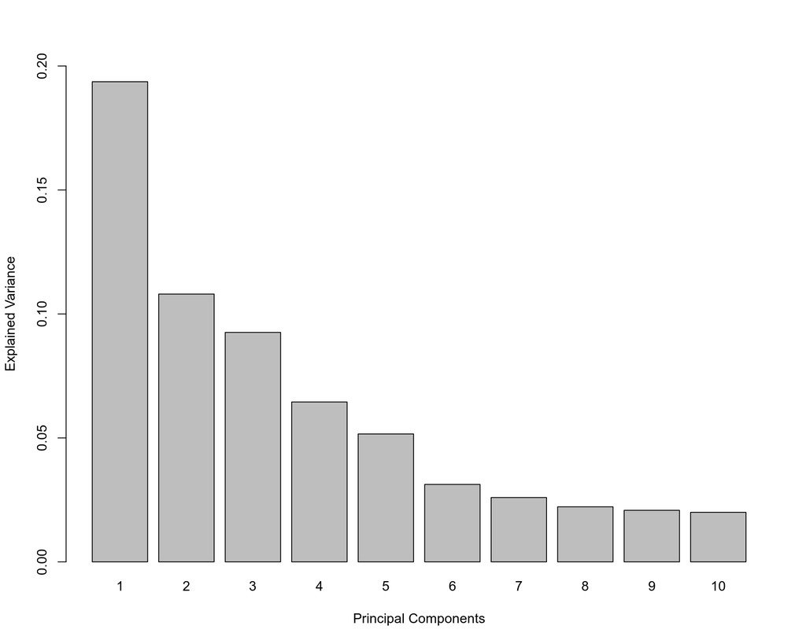

```r
plot(pca.expr,ylim=c(0,0.2))
```

The PCA shows that about 50% of the total variance is explained by the first 4-5 principal components. We will visualize PC1 vs. PC2 dependence coloring samples according to their diabetes status, gender, date and purity:

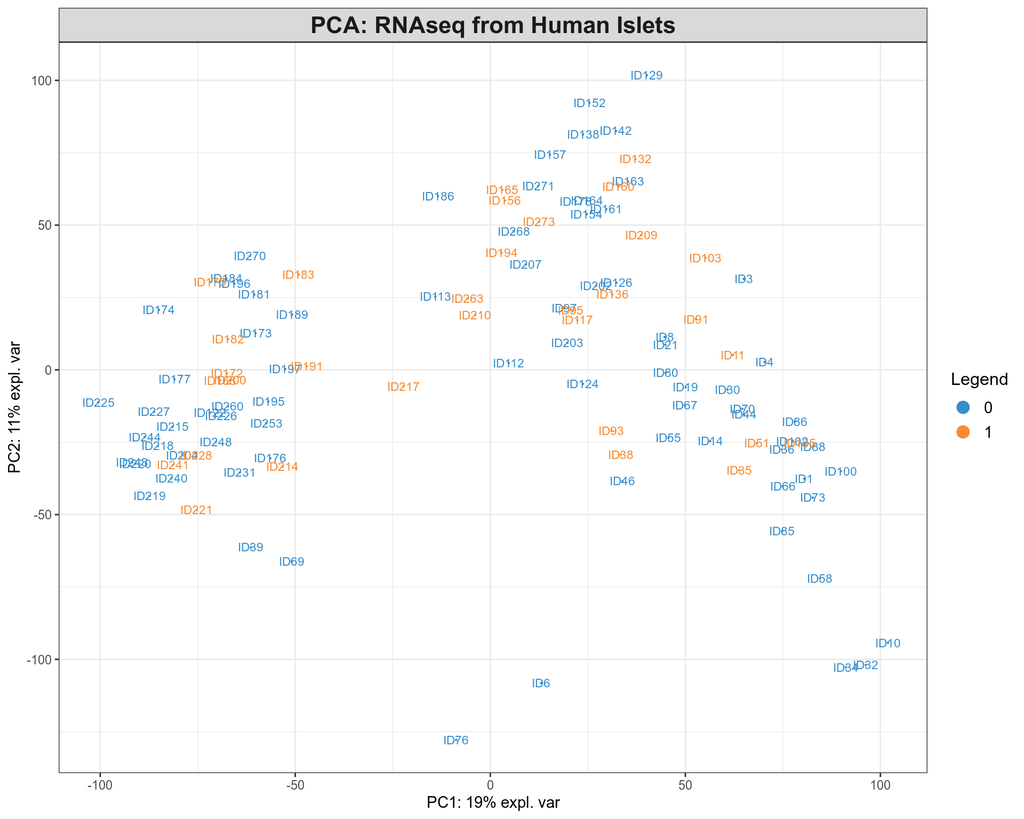

```r
plotIndiv(pca.expr,group=as.factor(htl$T2D),ind.names=TRUE,ellipse=FALSE,legend=TRUE,title="PCA: RNAseq from Human Islets")
```

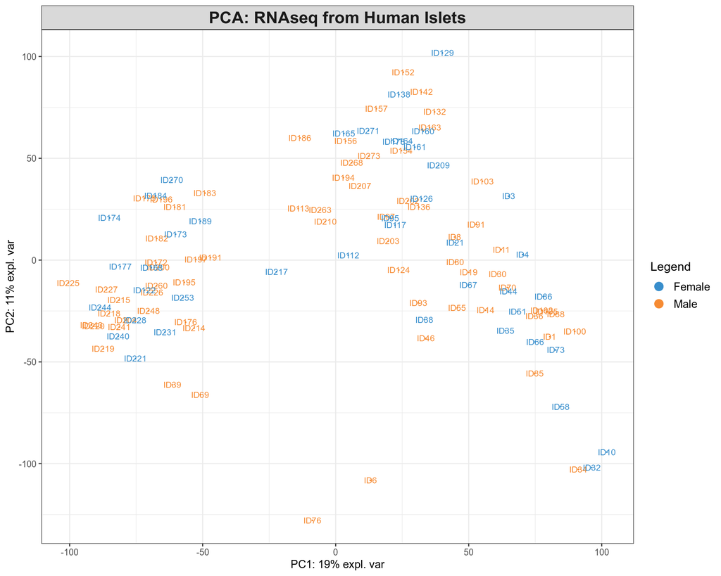

```r
plotIndiv(pca.expr,group=as.factor(htl$Gender),ind.names=TRUE,ellipse=FALSE,legend=TRUE,title="PCA: RNAseq from Human Islets")
```

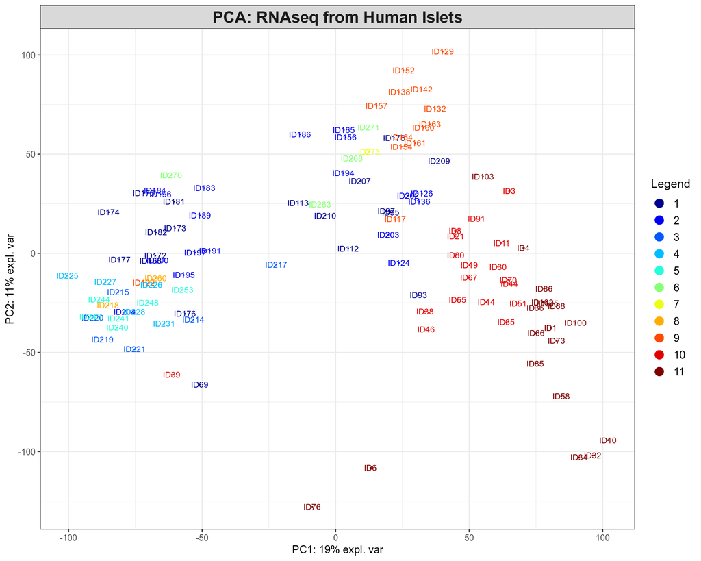

```r
plotIndiv(pca.expr,group=htl$RNA_Batch,ind.names=TRUE,ellipse=FALSE,legend=TRUE,title="PCA: RNAseq from Human Islets")
```

We see obvious clustering by batch but not by T2D or Sex on genome-wide level. To further quantify genome-wide batch-effetcs let us display how much of variation in each principal component is explained by the batch variables:

```r
htl$DIC<-as.factor(htl$DIC)
htl$Meth_Batch<-as.factor(htl$Meth_Batch)
htl$RNA_Batch<-as.factor(htl$RNA_Batch)
pc_adj_r_squared<-matrix(NA,ncol=dim(pca.expr$x)[2],nrow=dim(htl)[2])
for(i in 1:dim(pca.expr$x)[2])
{
  print(i)
  for(j in 1:dim(htl)[2])
  {
    pc_adj_r_squared[j,i]<-summary(lm(pca.expr$x[,i]~htl[,j]))$adj.r.squared
  }
}
```

```
## [1] 1
## [1] 2
## [1] 3
## [1] 4
## [1] 5
## [1] 6
## [1] 7
## [1] 8
## [1] 9
## [1] 10
```

```r
pc_adj_r_squared<-as.data.frame(pc_adj_r_squared)
colnames(pc_adj_r_squared)<-colnames(pca.expr$x)
rownames(pc_adj_r_squared)<-colnames(htl)
pc_adj_r_squared[pc_adj_r_squared<0]<-0
pc_adj_r_squared
```

```
##                     PC1         PC2         PC3        PC4        PC5
## Gender     0.0000000000 0.000000000 0.000000000 0.00000000 0.00000000
## Age        0.0162215328 0.000000000 0.000000000 0.01684206 0.00000000
## BMI        0.0000000000 0.005817483 0.005523857 0.00000000 0.00000000
## HbA1c      0.0000000000 0.000000000 0.000000000 0.03395993 0.00000000
## T2D        0.0000000000 0.015631741 0.035929700 0.05382920 0.00000000
## SI         0.0065533755 0.021800160 0.000554513 0.00000000 0.00000000
## Purity     0.0309022260 0.000000000 0.000000000 0.09967368 0.04415933
## DIC        0.0000000000 0.022069055 0.028733799 0.09384505 0.02530437
## Meth_Batch 0.2649699089 0.384031791 0.086851819 0.05248888 0.04395745
## RNA_Batch  0.6874731815 0.580253770 0.437199616 0.19695235 0.17074445
## Random     0.0003489087 0.000000000 0.000000000 0.00000000 0.00000000
##                     PC6        PC7          PC8         PC9         PC10
## Gender     0.0739859973 0.00000000 0.0212037265 0.000000000 0.0033046912
## Age        0.0002231299 0.00000000 0.0000000000 0.000000000 0.0157620897
## BMI        0.0000000000 0.01824427 0.0566392561 0.026104835 0.0000000000
## HbA1c      0.0000000000 0.05732866 0.0105911356 0.001088568 0.0000000000
## T2D        0.0034726832 0.02660199 0.0002757626 0.000000000 0.0003095176
## SI         0.0000000000 0.00000000 0.0029838634 0.004816774 0.0097484731
## Purity     0.0139971054 0.00000000 0.0209821781 0.005608209 0.0000000000
## DIC        0.0793816454 0.07978703 0.0039379658 0.089886675 0.0151742723
## Meth_Batch 0.0632440105 0.04580237 0.0000000000 0.000000000 0.0000000000
## RNA_Batch  0.1552135650 0.02159361 0.2484465577 0.055627386 0.3167283202
## Random     0.0000000000 0.00000000 0.0000000000 0.000000000 0.0021826300
```

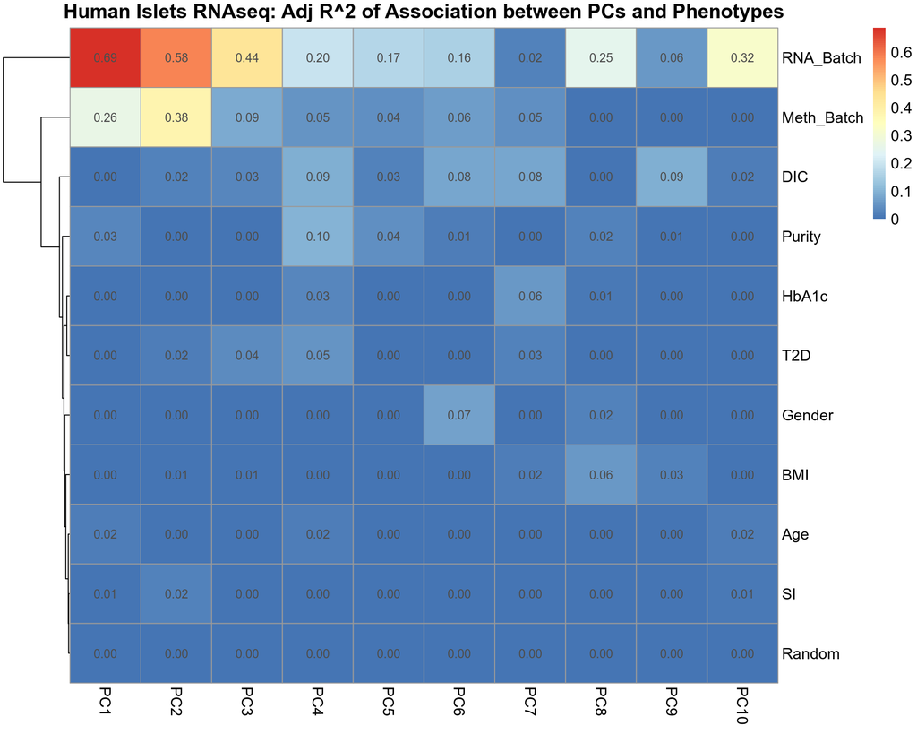

```r
library("pheatmap")
pheatmap(pc_adj_r_squared, display_numbers=TRUE, fontsize=12, cluster_cols=FALSE, main="Human Islets RNAseq: Adj R^2 of Association between PCs and Phenotypes")
```

Therefore we conclude that the biological signal (T2D) is hidden and covered by lots of technological noise. We need to urgently clean the expression data set from batch-effects. However, it is a naive idea to use ComBat and remove the batch because both T2D / HbA1c and the batch contribute to PC3, i.e. they are confounded, so removing the batch might remove some T2D / HbA1c related variation, I tried it and the result was not good, no T2D / HbA1c variation was left. Since T2D / HbA1c contribute to PC3-4 it is informative to look at the top loading of PC3-4 to have some idea which genes drive this component:

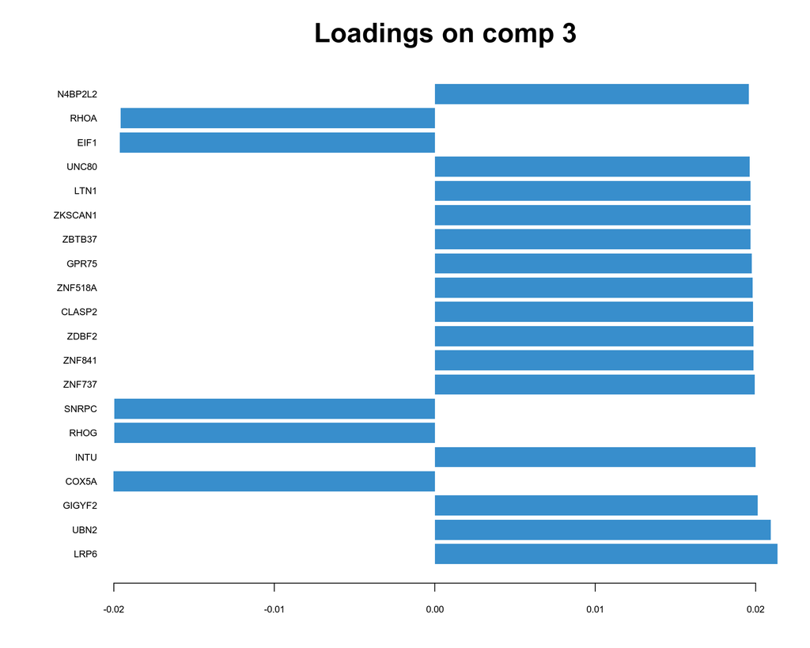

```r
plotLoadings(pca.expr,comp=3,method='median',contrib='max',ndisplay=20)
```

```r
head(sort(abs(pca.expr$loadings$X[,"PC3"]),decreasing=TRUE),20)
```

```
##       LRP6       UBN2     GIGYF2      COX5A       INTU       RHOG
## 0.02136569 0.02094920 0.02013541 0.02002686 0.02000277 0.01997264
##      SNRPC     ZNF737     ZNF841      ZDBF2     CLASP2    ZNF518A
## 0.01997217 0.01993318 0.01987398 0.01985889 0.01984217 0.01980889
##      GPR75     ZBTB37    ZKSCAN1       LTN1      UNC80       EIF1
## 0.01976813 0.01967753 0.01967149 0.01966578 0.01963435 0.01962925
##       RHOA    N4BP2L2
## 0.01956530 0.01956416
```

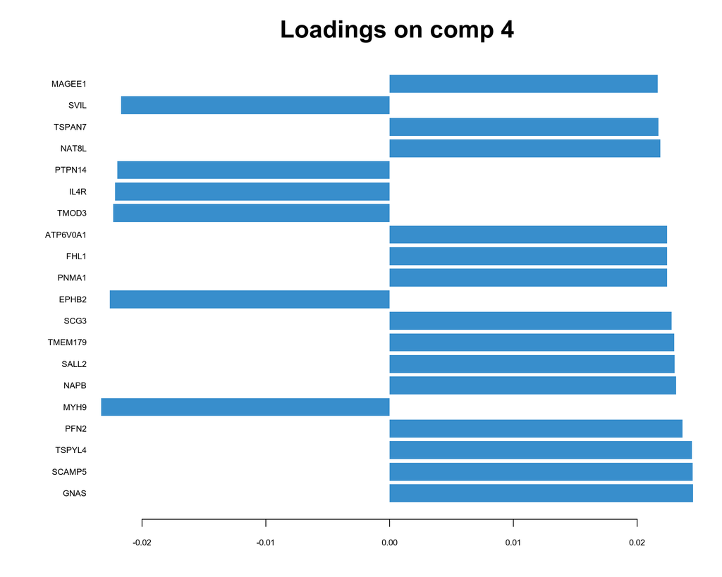

```r
plotLoadings(pca.expr,comp=4,method='median',contrib='max',ndisplay=20)
```

```r
head(sort(abs(pca.expr$loadings$X[,"PC4"]),decreasing=TRUE),20)
```

```
##       GNAS     SCAMP5     TSPYL4       PFN2       MYH9       NAPB
## 0.02452113 0.02448381 0.02443871 0.02365535 0.02331078 0.02314083
##      SALL2    TMEM179       SCG3      EPHB2      PNMA1       FHL1
## 0.02301519 0.02300353 0.02279357 0.02260770 0.02242724 0.02242552
##   ATP6V0A1      TMOD3       IL4R     PTPN14      NAT8L     TSPAN7
## 0.02242120 0.02231866 0.02218339 0.02198520 0.02188667 0.02170578
##       SVIL     MAGEE1
## 0.02170305 0.02165364
```

### PLS-DA Analysis of RNAdseq Gene Expression Data

Now we will perform PLS-DA analysis, for this purpose we are going to construct the X and Y matrices in order to maximize their covariance, cov(X,Y):

```r
gc()
```

```
##            used  (Mb) gc trigger  (Mb) max used  (Mb)
## Ncells  2119257 113.2    3982560 212.7  3982560 212.7
## Vcells 10183305  77.7   22937468 175.0 21273952 162.4
```

```r
library("mixOmics")
Y<-as.factor(as.character(htl$T2D))
summary(Y)
```

```
##  0  1
## 78 32
```

We have approximetaly 29% of T2D individuals which is not crazy unbalanced, so there is a hope that the model does not learn only the majority class. Important to mention that a very naive / stupid classifier that predicts Non-T2D for any given individual should thus achieve 71% accuracy of classification. So our PLS-DA model should be better than the naive classifier and outperform the lower threshold of 71%.

```r
my_folds=2
my_nrepeat=10
my_progressBar=FALSE
my_cpus=1
```

```r
gc()
```

```
##            used  (Mb) gc trigger  (Mb) max used  (Mb)
## Ncells  2119557 113.2    3982560 212.7  3982560 212.7
## Vcells 10184456  77.8   22937468 175.0 21273952 162.4
```

```r
expr_plsda.perf<-plsda(X, Y, ncomp=10)

ptm<-proc.time()
perf.plsda<-perf(expr_plsda.perf, validation='Mfold', folds=my_folds, progressBar=my_progressBar, nrepeat=my_nrepeat)
proc.time()-ptm
```

```
##    user  system elapsed
##  55.078   0.448  55.538
```

```r
perf.plsda
```

```
##
## Call:
##  perf.mixo_plsda(object = expr_plsda.perf, validation = "Mfold", folds = my_folds, nrepeat = my_nrepeat, progressBar = my_progressBar)
##
##  Main numerical outputs:
##  --------------------
##  Error rate (overall or BER) for each component and for each distance: see object$error.rate
##  Error rate per class, for each component and for each distance: see object$error.rate.class
##  Prediction values for each component: see object$predict
##  Classification of each sample, for each component and for each distance: see object$class
##  AUC values: see object$auc if auc = TRUE
##
##  Visualisation Functions:
##  --------------------
##  plot
```

```r
head(perf.plsda$error.rate)
```

```
## $overall
##         max.dist centroids.dist mahalanobis.dist
## comp1  0.2872727      0.3345455        0.3345455
## comp2  0.2681818      0.3009091        0.2990909
## comp3  0.2500000      0.2663636        0.2563636
## comp4  0.2154545      0.2281818        0.2127273
## comp5  0.2154545      0.2290909        0.2145455
## comp6  0.2190909      0.2445455        0.2209091
## comp7  0.2209091      0.2536364        0.2200000
## comp8  0.2190909      0.2454545        0.2190909
## comp9  0.2100000      0.2372727        0.2090909
## comp10 0.1827273      0.2036364        0.1827273
##
## $BER
##         max.dist centroids.dist mahalanobis.dist
## comp1  0.3923878      0.3630609        0.3630609
## comp2  0.3614183      0.3504006        0.3528045
## comp3  0.3338542      0.3251202        0.3217548
## comp4  0.2864583      0.2788462        0.2716346
## comp5  0.2781651      0.2813301        0.2729167
## comp6  0.2954728      0.3097356        0.2958333
## comp7  0.2958333      0.3143029        0.2933494
## comp8  0.2871795      0.3076122        0.2871795
## comp9  0.2816907      0.3018429        0.2801282
## comp10 0.2421875      0.2606170        0.2421875
```

```r
head(perf.plsda$error.rate.class)
```

```
## $max.dist
##       comp1     comp2     comp3     comp4     comp5     comp6     comp7
## 0 0.1410256 0.1384615 0.1333333 0.1166667 0.1282051 0.1128205 0.1166667
## 1 0.6437500 0.5843750 0.5343750 0.4562500 0.4281250 0.4781250 0.4750000
##      comp8     comp9   comp10
## 0 0.124359 0.1102564 0.100000
## 1 0.450000 0.4531250 0.384375
##
## $centroids.dist
##       comp1     comp2     comp3     comp4     comp5     comp6     comp7
## 0 0.2948718 0.2320513 0.1846154 0.1576923 0.1564103 0.1538462 0.1692308
## 1 0.4312500 0.4687500 0.4656250 0.4000000 0.4062500 0.4656250 0.4593750
##       comp8     comp9   comp10
## 0 0.1589744 0.1474359 0.124359
## 1 0.4562500 0.4562500 0.396875
##
## $mahalanobis.dist
##       comp1    comp2     comp3     comp4     comp5     comp6     comp7
## 0 0.2948718 0.224359 0.1653846 0.1307692 0.1333333 0.1166667 0.1179487
## 1 0.4312500 0.481250 0.4781250 0.4125000 0.4125000 0.4750000 0.4687500
##      comp8     comp9   comp10
## 0 0.124359 0.1102564 0.100000
## 1 0.450000 0.4500000 0.384375
```

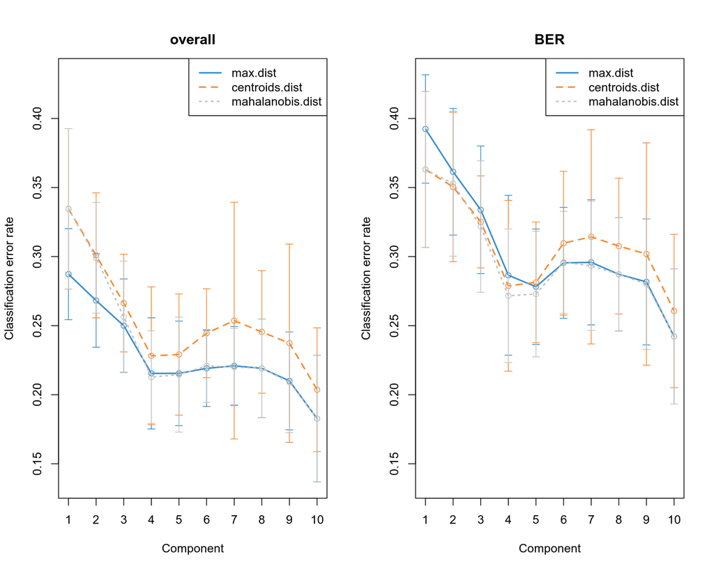

```r
plot(perf.plsda,overlay='dist',sd=TRUE)
```

We can see that the BER Mahalanobis seems to reach its plateau or weak minimum at ncomp=4, so we will use 4 PLS components for further PLS-DA analysis.

```r
gc()
```

```
##            used  (Mb) gc trigger  (Mb) max used  (Mb)
## Ncells  2168268 115.8    3982560 212.7  3982560 212.7
## Vcells 14925388 113.9   41800250 319.0 41800250 319.0
```

```r
expr_plsda<-plsda(X, Y, ncomp=4)
expr_plsda$explained_variance
```

```
## $X
##     comp 1     comp 2     comp 3     comp 4
## 0.08818242 0.10709984 0.11127793 0.06890462
##
## $Y
##    comp 1    comp 2    comp 3    comp 4
## 1.0000000 0.7022639 0.4977943 0.3267307
```

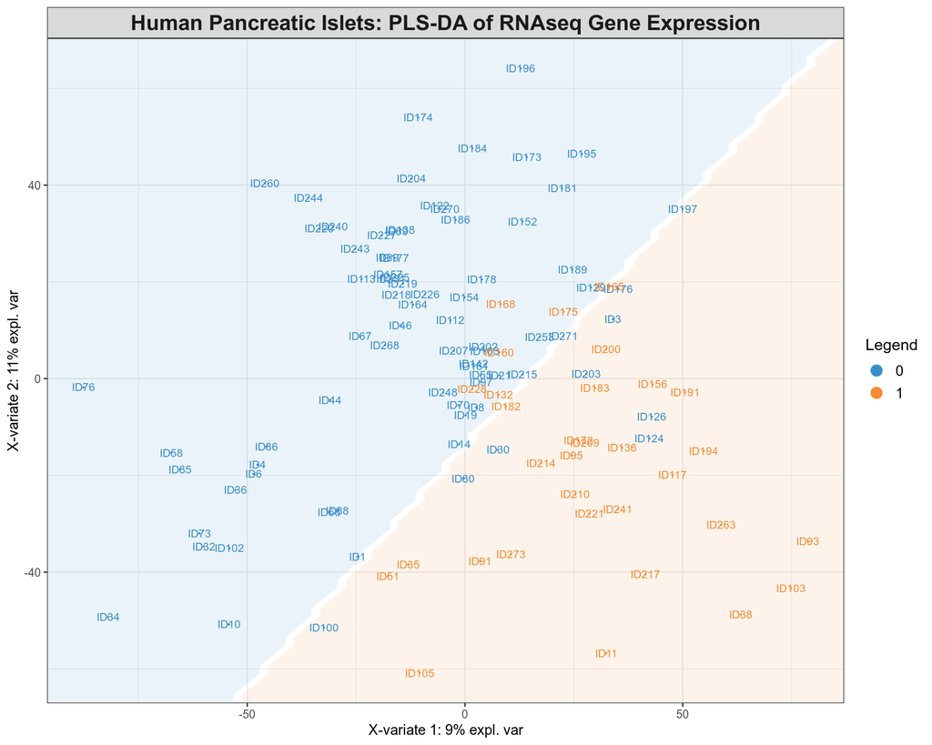

```r
background = background.predict(expr_plsda, comp.predicted=2, dist = "mahalanobis.dist")
plotIndiv(expr_plsda, comp=c(1,2), group=Y, ind.names=TRUE, ellipse=FALSE, background=background, legend=TRUE, title="Human Pancreatic Islets: PLS-DA of RNAseq Gene Expression")
```

Plotting the loadings of the two PLS components we can see which genes are responsible for the linear separation of the T2D and non-T2D individuals:

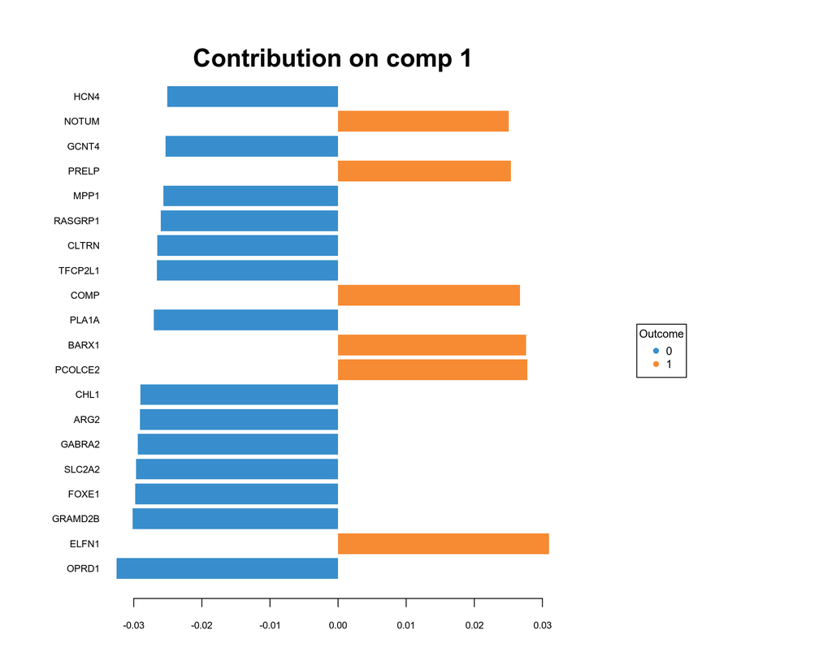

```r
plotLoadings(expr_plsda, comp=1, method='median', contrib='max', ndisplay=20)
```

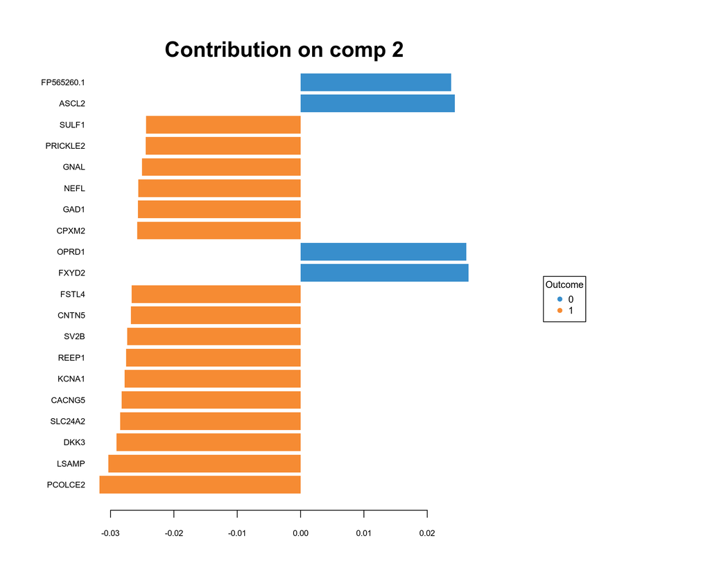

```r
plotLoadings(expr_plsda, comp=2, method='median', contrib='max', ndisplay=20)
```

### Sparse PLS-DA Analysis of RNAseq Gene Expression Data

Many of the genes included to the PLS-DA analysis are actually non-informative and bring noise to the analysis. Therefore one needs to apply sparse cleaning algorithm to select a subset of genes that best discriminate between diabetics and non diabetics. We will use LASSO for selection of most informative genes. The tuning procedure below is performed on one component at a time and selects an optimal number of genes that provide lowest error rate. Since from the previous analysis we concluded that the minimal error rate is achieved on the first 4 principal components, we will use ncomp=4 in the sPLS-DA analysis.

```r
gc()
```

```
##            used  (Mb) gc trigger  (Mb) max used  (Mb)
## Ncells  2177235 116.3    3982560 212.7  3982560 212.7
## Vcells 19202425 146.6   41800250 319.0 41800250 319.0
```

```r
list.keepX<-c(1:10,seq(20,50,10))

ptm<-proc.time()
tune.splsda.islets<-tune.splsda(X,Y,ncomp=4,validation='Mfold',folds=my_folds,progressBar=my_progressBar,dist='mahalanobis.dist',test.keepX=list.keepX,nrepeat=my_nrepeat)
proc.time()-ptm
```

```
##    user  system elapsed
##  84.005   0.196  84.214
```

```r
head(tune.splsda.islets$error.rate)
```

```
##       comp1     comp2     comp3     comp4
## 1 0.2961939 0.2308093 0.1647436 0.1866587
## 2 0.2892228 0.2281651 0.1681490 0.1901442
## 3 0.2696715 0.2130208 0.1747596 0.1823317
## 4 0.2678285 0.2108173 0.1725561 0.1819712
## 5 0.2533253 0.2064103 0.1741186 0.1854567
## 6 0.2384615 0.2035657 0.1719151 0.1876603
```

```r
tune.splsda.islets$choice.keepX
```

```
## comp1 comp2 comp3 comp4
##    40    50    30    50
```

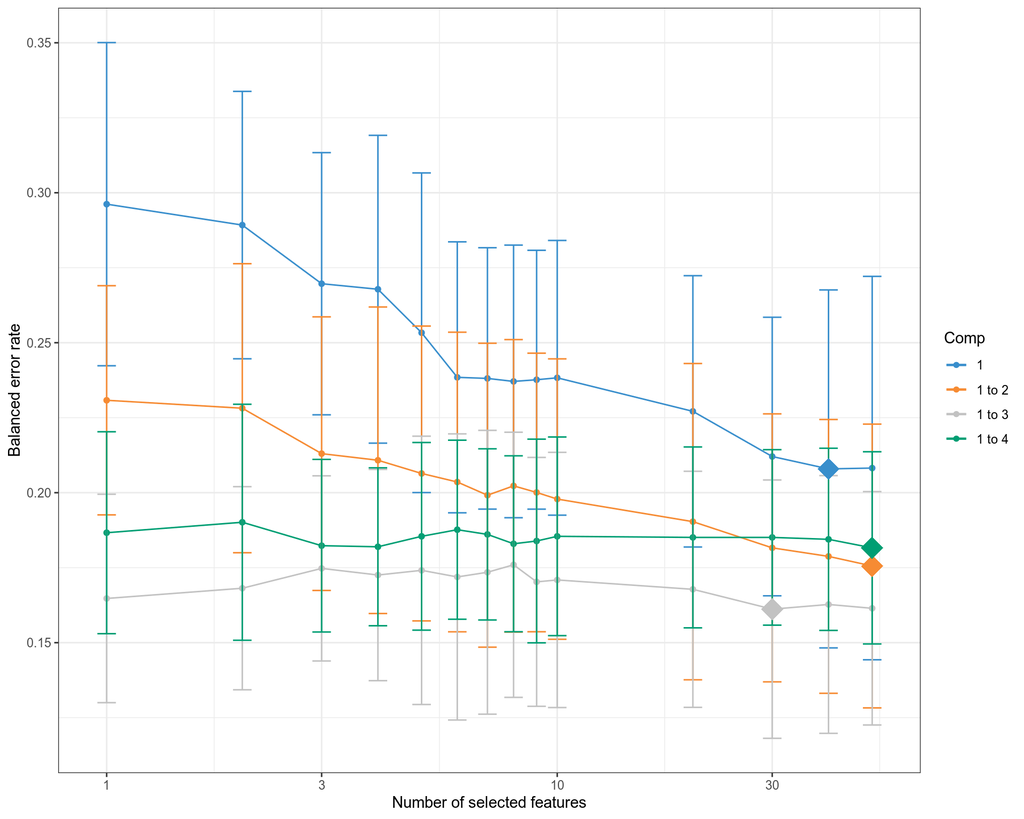

```r
plot(tune.splsda.islets,optimal=TRUE,sd=TRUE)
```

```r
gc()
```

```
##            used  (Mb) gc trigger  (Mb) max used  (Mb)
## Ncells  2190063 117.0    3982560 212.7  3982560 212.7
## Vcells 19221550 146.7   45756870 349.1 45756870 349.1
```

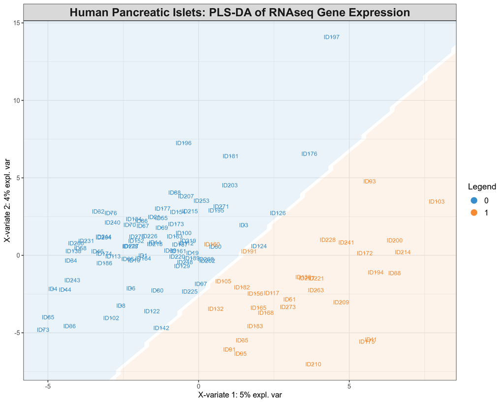

```r
select.keepX<-as.numeric(tune.splsda.islets$choice.keepX)
splsda.islets<-splsda(X, Y, ncomp=4, keepX=select.keepX)
background = background.predict(splsda.islets, comp.predicted=2, dist = "mahalanobis.dist")
plotIndiv(splsda.islets,comp=c(1,2),group=Y,ind.names=TRUE,ellipse=FALSE,background=background,legend=TRUE,title="Human Pancreatic Islets: PLS-DA of RNAseq Gene Expression")
```

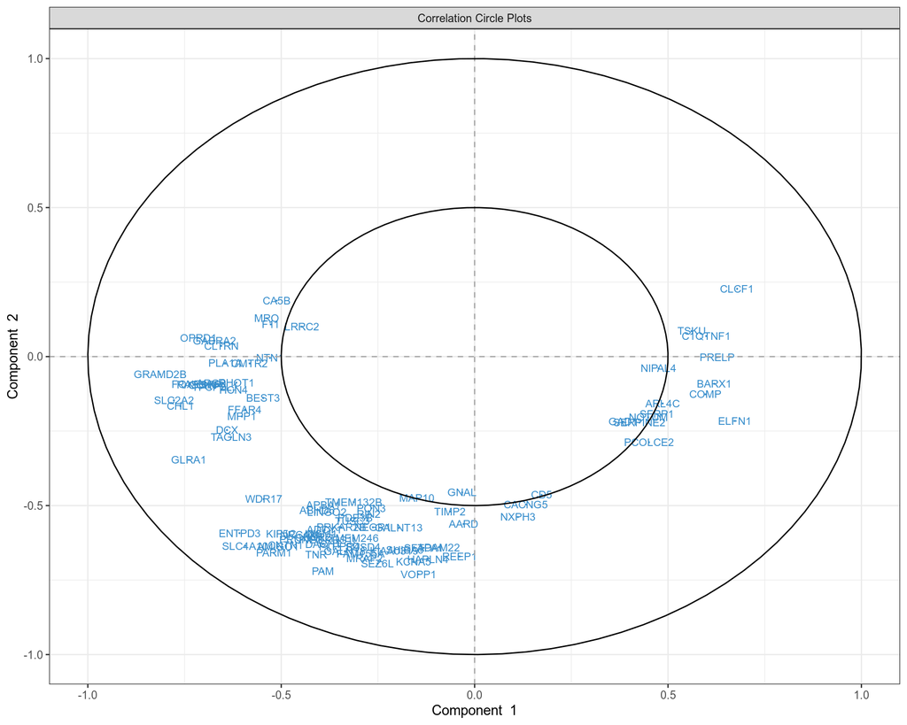

```r
plotVar(splsda.islets,comp=c(1,2),var.names=list(rownames(expr)),cex=3)
```

```r
head(sort(abs(splsda.islets$loadings$X[,"comp1"]),decreasing=TRUE),10)
```

```
##     OPRD1     ELFN1   GRAMD2B     FOXE1    SLC2A2    GABRA2      ARG2
## 0.4180371 0.3463346 0.3081484 0.2903261 0.2849719 0.2719030 0.2595628
##      CHL1   PCOLCE2     BARX1
## 0.2544124 0.1973705 0.1888141
```

```r
head(sort(abs(splsda.islets$loadings$X[,"comp2"]),decreasing=TRUE),10)
```

```
##     VOPP1  KIAA0319    SHISA6      AARD    PRUNE2     REEP1    HAPLN4
## 0.3570745 0.3493326 0.3456321 0.2684342 0.2674820 0.2560806 0.2461071
##       TNR   FAM155A       PAM
## 0.2454629 0.2276867 0.1941422
```

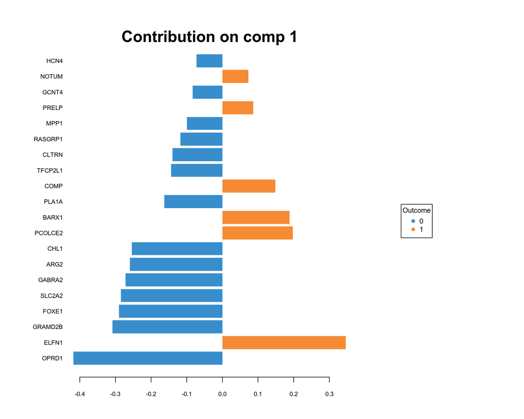

```r
plotLoadings(splsda.islets,comp=1,method='median',contrib='max',ndisplay=20)
```

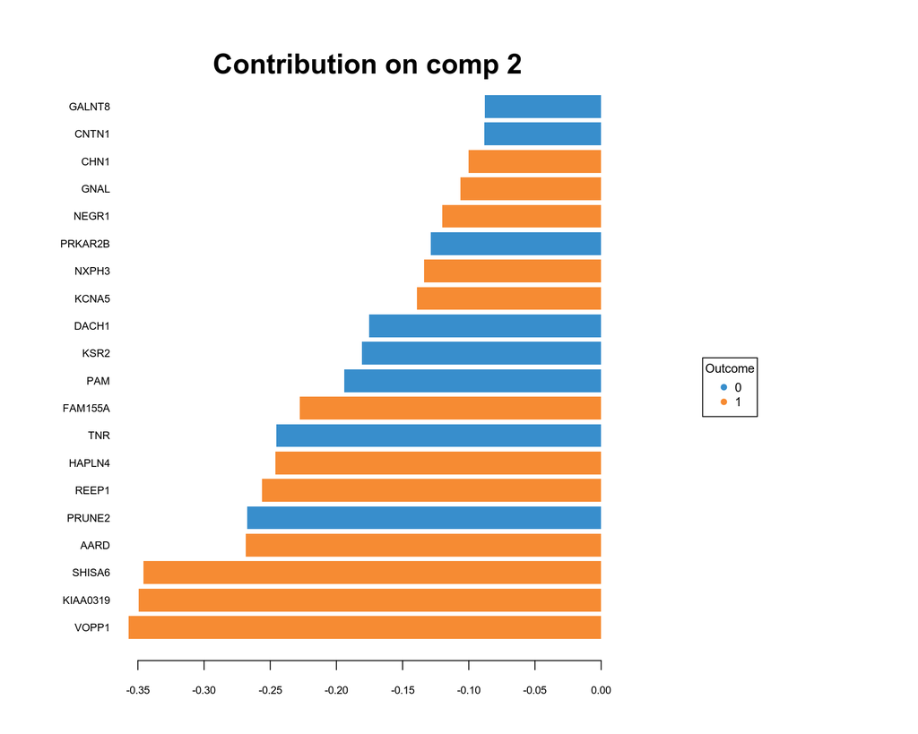

```r
plotLoadings(splsda.islets,comp=2,method='median',contrib='max',ndisplay=20)
```

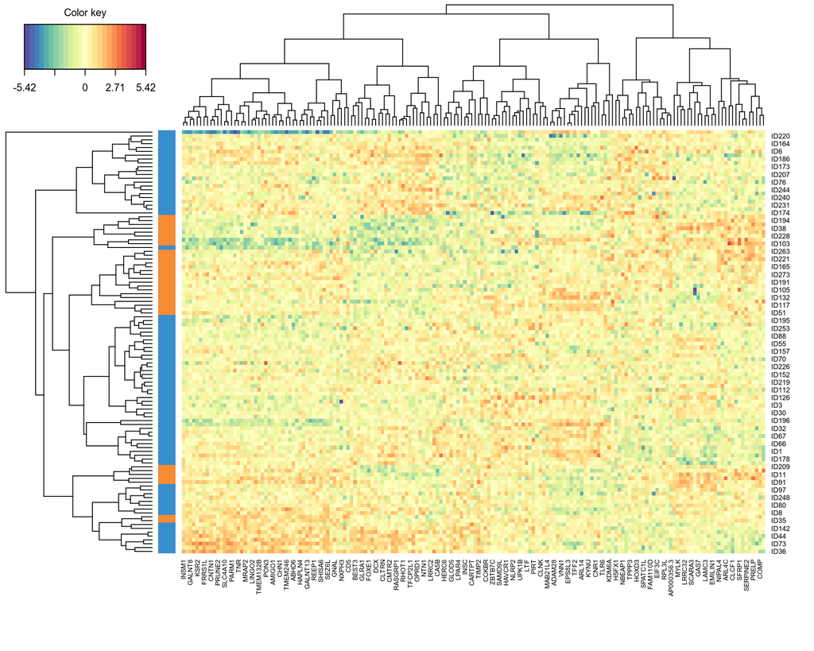

```r
cim(splsda.islets,row.sideColors=color.mixo(Y),margins=c(8,4))
```

### Predicting T2D Status from sPLS-DA Model

Finally we will randomly split the RNAseq data set into training (80% of samples) and validation (20% of samples) sets. This is needed to validate predictions of sPLS-DA trained on the training data set.

We are going to perform again the tuning of the sPLS-DA model on the training data set. From the previous analysis we know that first 4 PLS components minimize the mahalanobis.dist balanced error rate, so we will use ncomp = 4 and re-tune the optimal numbers of genes although they should be quite similar to the ones obtained in the previous section as the training set comprises 80% of the full data set. For this purpose, we will choose again a small step of the gene grid list.keepX. Now we will apply the tuned and trained model to the validation data set and generate predictions of T2D status and compute the accuracy of the prediction.

```r
gc()
```

```
##            used  (Mb) gc trigger  (Mb) max used  (Mb)
## Ncells  2239473 119.7    3982561 212.7  3982561 212.7
## Vcells 23589106 180.0   45756870 349.1 45756870 349.1
```

```r
N_repeat<-100
library("mixOmics")
library("ROCit")
test_samples<-selected_ind[sample(1:length(selected_ind),round(length(selected_ind)*0.2))]
train_samples<-selected_ind[!selected_ind%in%test_samples]
comp1_auc<-vector()
comp1_tpr<-matrix(NA,ncol=length(test_samples)+1,nrow=N_repeat)
comp1_fpr<-matrix(NA,ncol=length(test_samples)+1,nrow=N_repeat)
comp2_auc<-vector()
comp2_tpr<-matrix(NA,ncol=length(test_samples)+1,nrow=N_repeat)
comp2_fpr<-matrix(NA,ncol=length(test_samples)+1,nrow=N_repeat)
comp1_acc<-vector()
comp2_acc<-vector()
for(k in 1:N_repeat)
{
  print(paste0("Working with split No.", k))
  gc()
  set.seed(k+100)
  test_samples<-colnames(expr)[sample(1:length(colnames(expr)),round(length(colnames(expr))*0.2))]
  train_samples<-colnames(expr)[!colnames(expr)%in%test_samples]

  X.train<-X[match(train_samples,rownames(X)),]
  X.test<-X[match(test_samples,rownames(X)),]
  Y.train<-as.factor(as.character(htl[match(train_samples,rownames(htl)),]$T2D))
  Y.test<-as.factor(as.character(htl[match(test_samples,rownames(htl)),]$T2D))

  list.keepX<-c(1:10,seq(20,50,10))
  tune.splsda.train.expr<-tune.splsda(X.train, Y.train, ncomp=4, validation='Mfold', folds=my_folds,
                                     progressBar=my_progressBar, dist='mahalanobis.dist', logratio="none",
                                     test.keepX=list.keepX, nrepeat=my_nrepeat)
  splsda.expr.train<-splsda(X.train, Y.train, logratio='none', ncomp=4,
                           keepX=as.numeric(tune.splsda.train.expr$choice.keepX))

  splsda.expr.predict<-predict(splsda.expr.train, X.test, dist='mahalanobis.dist')

  expr_predict1<-splsda.expr.predict$predict[,,1][,2]
  roc_obj1<-rocit(as.numeric(expr_predict1),as.numeric(as.character(Y.test)))
  expr_predict2<-splsda.expr.predict$predict[,,2][,2]
  roc_obj2<-rocit(as.numeric(expr_predict2),as.numeric(as.character(Y.test)))

  comp1_auc<-append(comp1_auc,roc_obj1$AUC)
  print(paste0("Classification ROC AUC from Expression PLS Component 1: ", roc_obj1$AUC))
  comp1_tpr[k,]<-roc_obj1$TPR
  comp1_fpr[k,]<-roc_obj1$FPR
  comp2_auc<-append(comp2_auc,roc_obj2$AUC)
  print(paste0("Classification ROC AUC from Expression PLS Component 2: ", roc_obj2$AUC))
  comp2_tpr[k,]<-roc_obj2$TPR
  comp2_fpr[k,]<-roc_obj2$FPR

  print(table(splsda.expr.predict$class$mahalanobis.dist[,1],Y.test))
  acc1<-round((sum(diag(table(splsda.expr.predict$class$mahalanobis.dist[,1],Y.test)))/sum(table(splsda.expr.predict$class$mahalanobis.dist[,1],Y.test)))*100)
  print(paste0("Classification Accuracy from PLS Component 1: ", acc1))
  print(table(splsda.expr.predict$class$mahalanobis.dist[,2],Y.test))
  acc2<-round((sum(diag(table(splsda.expr.predict$class$mahalanobis.dist[,2],Y.test)))/sum(table(splsda.expr.predict$class$mahalanobis.dist[,2],Y.test)))*100)
  print(paste0("Classification Accuracy from PLS Component 2: ", acc2))

  comp1_acc<-append(comp1_acc,acc1)
  comp2_acc<-append(comp2_acc,acc2)
  print("***********************************************************")
}
```

```
## [1] "Working with split No.1"
## [1] "Classification ROC AUC from Expression PLS Component 1: 0.919642857142857"
## [1] "Classification ROC AUC from Expression PLS Component 2: 0.991071428571429"
##    Y.test
##      0  1
##   0 13  1
##   1  1  7
## [1] "Classification Accuracy from PLS Component 1: 91"
##    Y.test
##      0  1
##   0 13  0
##   1  1  8
## [1] "Classification Accuracy from PLS Component 2: 95"
## [1] "***********************************************************"
## [1] "Working with split No.2"
```

[output cut: 1385 more lines]

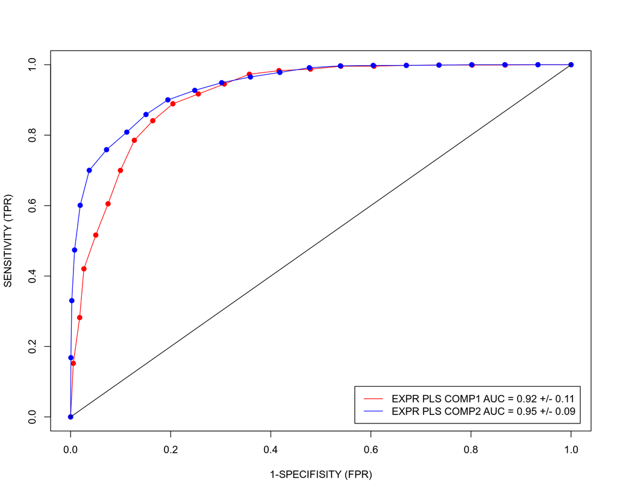

```r
plot(colMeans(comp1_fpr),colMeans(comp1_tpr),col="red",type="o",ylab="SENSITIVITY (TPR)",xlab="1-SPECIFISITY (FPR)",pch=19)
lines(colMeans(comp2_fpr),colMeans(comp2_tpr),col="blue",type="o",pch=19)
lines(c(0,1),c(0,1),col="black")
legend("bottomright",legend=c(paste0("EXPR PLS COMP1 AUC = ",round(mean(comp1_auc),2)," +/- ",round(2*sd(comp1_auc),2)),paste0("EXPR PLS COMP2 AUC = ",round(mean(comp2_auc),2)," +/- ",round(2*sd(comp2_auc),2))),col=c("red","blue"),inset=0.02,lty=c(1,1))
```

```r
write.table(comp1_auc,file="Comp1_PLS_Expr_AUC.txt",col.names=FALSE,row.names=FALSE,quote=FALSE,sep="\t")
write.table(comp1_tpr,file="Comp1_PLS_Expr_TPR.txt",col.names=FALSE,row.names=FALSE,quote=FALSE,sep="\t")
write.table(comp1_fpr,file="Comp1_PLS_Expr_FPR.txt",col.names=FALSE,row.names=FALSE,quote=FALSE,sep="\t")
write.table(comp2_auc,file="Comp2_PLS_Expr_AUC.txt",col.names=FALSE,row.names=FALSE,quote=FALSE,sep="\t")
write.table(comp2_tpr,file="Comp2_PLS_Expr_TPR.txt",col.names=FALSE,row.names=FALSE,quote=FALSE,sep="\t")
write.table(comp2_fpr,file="Comp2_PLS_Expr_FPR.txt",col.names=FALSE,row.names=FALSE,quote=FALSE,sep="\t")
write.table(comp1_acc,file="Comp1_PLS_Expr_Acc.txt",col.names=FALSE,row.names=FALSE,quote=FALSE,sep="\t")
write.table(comp2_acc,file="Comp2_PLS_Expr_Acc.txt",col.names=FALSE,row.names=FALSE,quote=FALSE,sep="\t")
```

```r
gc()
```

```
##            used  (Mb) gc trigger  (Mb)  max used  (Mb)
## Ncells  2280499 121.8    3982563 212.7   3982563 212.7
## Vcells 29252026 223.2  101810050 776.8 103451271 789.3
```

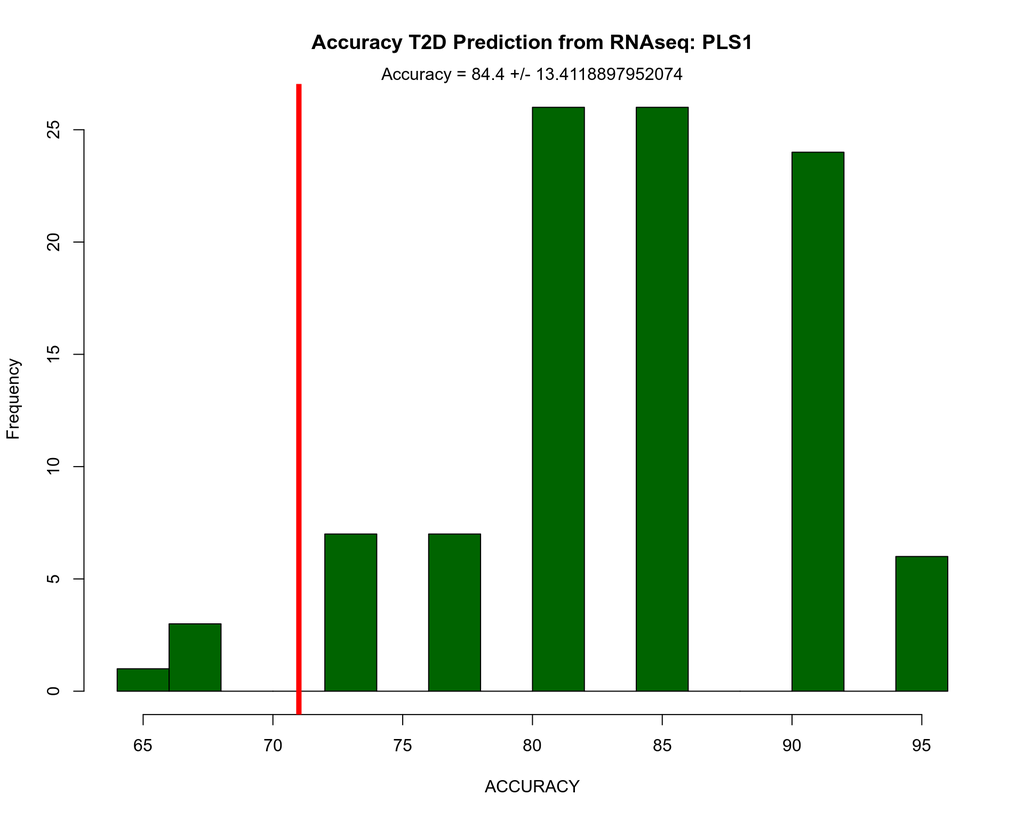

```r
comp1_acc_arch<-as.numeric(scan("Comp1_PLS_Expr_Acc.txt",what="character"))
comp2_acc_arch<-as.numeric(scan("Comp2_PLS_Expr_Acc.txt",what="character"))

#comp1_acc_arch<-c(comp1_acc,comp1_acc_arch)
#comp2_acc_arch<-c(comp2_acc,comp2_acc_arch)

hist(comp1_acc_arch,breaks=20,xlab="ACCURACY",main="Accuracy T2D Prediction from RNAseq: PLS1",col="darkgreen")
abline(v=71,col="red",lwd=5)
mtext(paste0("Accuracy = ",mean(comp1_acc_arch)," +/- ",2*sd(comp1_acc_arch)))
```

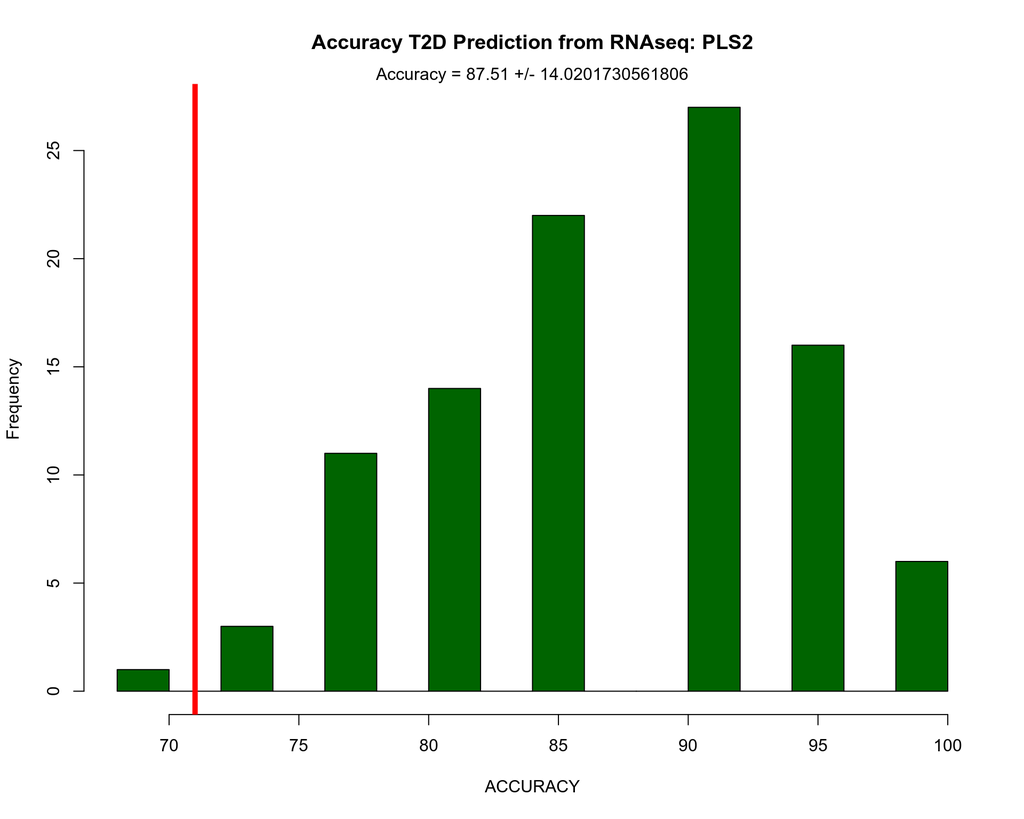

```r
hist(comp2_acc_arch,breaks=20,xlab="ACCURACY",main="Accuracy T2D Prediction from RNAseq: PLS2",col="darkgreen")
abline(v=71,col="red",lwd=5)
mtext(paste0("Accuracy = ",mean(comp2_acc_arch)," +/- ",2*sd(comp2_acc_arch)))
```

We can compute how significantly different is the accuracy of the PLS-DA model compared to the naive 71% accuracy:

```r
gc()
```

```
##            used  (Mb) gc trigger  (Mb)  max used  (Mb)
## Ncells  2280478 121.8    3982563 212.7   3982563 212.7
## Vcells 29251401 223.2  101810050 776.8 103451271 789.3
```

```r
sum(comp1_acc_arch<=71)/length(comp1_acc_arch)
```

```
## [1] 0.04
```

```r
sum(comp2_acc_arch<=71)/length(comp2_acc_arch)
```

```
## [1] 0.01
```

```r
rm(list=ls())
gc()
```

```
##           used  (Mb) gc trigger  (Mb)  max used  (Mb)
## Ncells 2125879 113.6    3982563 212.7   3982563 212.7
## Vcells 8097346  61.8   81448040 621.4 103451271 789.3
```